```python
%run workshop.py
```

# ความยุติธรรมของ AI ในวงการแพทย์

อยากจะชวนทุกคนลองถอดแว่นของแพทย์แล้วมาลองใส่แว่นของนักพัฒนา AI กันดูสักชั่วโมง ในวันนี้เราจะมาคุยกันถึงความรู้พื้นฐานเกี่ยวกับการพัฒนา AI สำหรับการประยุกต์ใช้ทางการแพทย์ แนวคิดเรื่องความยุติธรรม (fairnes) และอคติ (bias) ของการพัฒนา AI ผลกระทบของอคติเหล่านั้น และแนวทางเบื้องต้นในการสร้าง AI ที่มีความยุติธรรม

ไม่ต้องกังวลถ้าคุณไม่มีประสบการณ์ในการเขียนโปรแกรมหรือ AI มาก่อน บทความนี้ (ซึ่งนักวิทยาศาสตร์ข้อมูลมักเรียกว่า *notebook*) จะเริ่มจากการนำเสนอกระบวนการทั้งหมดของการสร้าง machine learning อย่างกระชับ และพวกเราเตรียมโค้ดโค้ดที่จำเป็นไว้ให้เรียบร้อยแล้ว

## ส่วนที่ 1: การสร้างโมเดล AI หมายถึงอะไร

การแก้ปัญหาด้วย AI ไม่มีคำตอบที่สมบูรณ์แบบหรือสูตรสำเร็จ เพราะแต่ละปัญหาต้องใช้แนวคิดและวิธีการที่ต่างกันไปตามรายละเอียด อย่างไรก็ตาม จุดเริ่มต้นคือการทำความเข้าใจปัญหา ข้อมูลที่มีอยู่ และเป้าหมายที่เราต้องการ

ตัวอย่างปัญหาที่พบบ่อยในบริบททางการแพทย์ ได้แก่ การวินิจฉัยผู้ป่วยจากอาการของโรค การคัดกรองโรคจากภาพถ่ายทางการแพทย์ หรือการค้นคว้าวัคซีนใหม่เมื่อเกิดโรคระบาด

แผนภาพด้านล่างแสดงกระบวนการของ machine learning โดยอธิบายขั้นตอนโดยย่อของการสร้างโมเดล AI เพื่อแก้ปัญหาที่กำหนดและบรรลุเป้าหมายที่ตั้งไว้

[figure not shown]

*ที่มา: https://towardsdatascience.com/wp-content/uploads/2024/11/1_dlG-Cju5ke-DKp8DQ9hiA@2x.jpeg*

1. **การเก็บรวบรวมข้อมูล (Data Collection)**

   ขั้นตอนแรกคือการรวบรวมข้อมูลทางการแพทย์ที่เกี่ยวข้องกับปัญหา เช่น ข้อมูลเวชระเบียน ผลการตรวจจากห้องปฏิบัติการ หรือภาพถ่ายทางการแพทย์ นักพัฒนา AI จะต้องเข้าใจปัญหาอย่างลึกซึ้ง โดยเฉพาะในบริบททางการแพทย์ และควรหาข้อมูลหรือทรัพยากรที่เหมาะสมในการนำมาสร้าง AI ให้ได้อย่างมีประสิทธิภาพ
2. **การทำความสะอาดข้อมูล (Data Cleaning)**

   ข้อมูลดิบมักมีข้อผิดพลาด เช่น ค่าที่ขาดหาย เก็บมาไม่ครบ หรือความไม่สอดคล้องกัน เราจึงต้องตรวจสอบและปรับปรุงข้อมูลเหล่านี้อย่างรอบคอบเพื่อให้ข้อมูลมีความถูกต้องและน่าเชื่อถือ
3. **การสร้างฟีเจอร์ (Feature Engineering)** เราจะจัดระเบียบข้อมูล และสร้างข้อมูลที่สำคัญที่ไม่ได้มีอยู่ในข้อมูลดิบ เช่น การคำนวณ BMI จากส่วนสูงและน้ำหนัก หรือการติดตามการเปลี่ยนแปลงของค่าตรวจทางห้องปฏิบัติการตามช่วงเวลา ซึ่งทำให้ AI ได้ใช้ข้อมูลที่สำคัญ แทนที่จะให้ AI เห็นแต่ข้อมูลดิบ ในขั้นตอนนี้ เราจะทำให้เกิด *inductive bias* (อคติเชิงอุปนัย) ซึ่งเกิดจากการคาดเดาว่าฟีเจอร์ไหนสำคัญหรือไม่สำคัญ
4. **การฝึกสอนโมเดล (Model Training)**

   โมเดล AI จะเรียนรู้รูปแบบจากข้อมูลและเป้าหมายที่กำหนด หลังจากที่นักพัฒนา AI กำหนดข้อจำกัดหรือกฎเกณฑ์ของข้อมูลเหล่านั้น ตัวอย่างของขั้นตอนนี้เช่น การวิเคราะห์ความสัมพันธ์ระหว่างโปรตีนกับ docking site หรือการจำรูปแบบของภาวะหยุดหายใจขณะหลับกับสัญญาณ SpO2
5. **การประเมินผล (Evaluation)**

   หลังจากเราสร้างโมเดลขึ้นมาจากข้อมูลแล้ว จะต้องมีการประเมินประสิทธิภาพของโมเดลโดยใช้ตัวชี้วัดต่าง ๆ เช่น sensitivity และ specificity รวมถึงการตรวจสอบอคติเพื่อให้แน่ใจว่าโมเดลมีความยุติธรรมและแม่นยำกับกลุ่มผู้ป่วยที่หลากหลายก่อนนำไปใช้จริง
6. **การนำไปใช้งาน (Deployment)**

   เมื่อโมเดลผ่านการตรวจสอบแล้ว จะนำไปเชื่อมต่อกับระบบของโรงพยาบาล เช่น การแจ้งเตือนผลตรวจที่ผิดปกติ โดยจะต้องมีการฝึกอบรมบุคลากรและจัดให้มีมาตรการติดตามผลอย่างเหมาะสม
7. **การติดตามผล (Monitoring)**

   หลังจากนำไปใช้งานจริง จะต้องมีการติดตามประสิทธิภาพของโมเดลอย่างต่อเนื่อง เช่นเดียวกับแนวทางเวชปฏิบัติที่มีการปรับปรุงอยู่เสมอ โมเดลก็จะได้รับการอัปเดตเมื่อมีข้อมูลใหม่หรือพบแนวทางในการปรับปรุง

กระบวนการนี้คือการสร้าง AI ที่มาสนับสนุนการปฏิบัติงานทางคลินิก โดยยังคงรักษาความปลอดภัยและความน่าเชื่อถือ เพราะความเชี่ยวชาญของแพทย์ยังคงมีความสำคัญในการแปลผลและตัดสินใจขั้นสุดท้าย รวมไปถึงความเข้าใจในปัญหาและการสร้างโมเดล AI

## ส่วนที่ 2: เริ่มสร้างโมเดล AI ทางการแพทย์ชิ้นแรก

เนื่องจากเราจะพูดถึงความยุติธรรมใน AI กันเป็นเรื่องหลัก เลยอยากทำความเข้าใจกันก่อนว่า “ความยุติธรรม” หมายถึงอะไรในบริบทของ AI

เพื่อให้เห็นภาพ ลองจินตนาการว่าเรากำลังอยู่ในห้องพิจารณาคดี และผู้พิพากษาในคดีนี้คือระบบ AI หากเราต้องการให้ระบบนี้ “ยุติธรรม” เราย่อมไม่อยากให้ผู้พิพากษาพิจารณาเพศ เชื้อชาติ หรือศาสนาในการตัดสินคดี เพราะเราเชื่อในหลักการที่ว่าผู้ชายและผู้หญิง คนต่างเชื้อชาติ และผู้ที่นับถือศาสนาต่างกัน ควรได้รับการปฏิบัติอย่างเท่าเทียมกันในศาล ดังนั้น เราจึงคาดหวังให้ AI ใช้หลักการนั้นและไม่มีอคติต่อคนกลุ่มใดกลุ่มหนึ่ง

เช่นเดียวกับในสถานการณ์ทางการแพทย์ ลองพิจารณากรณีของโรคมะเร็งปอด หากมีระบบ AI ที่ใช้ช่วยวินิจฉัยโรคมะเร็งปอด เราก็คาดหวังให้ระบบนั้นไม่เลือกปฏิบัติตามเพศ เนื่องจากเราทราบกันดีว่าชายและหญิงมีปัจจัยทางชีวภาพที่เกี่ยวข้องกับโรคนี้ใกล้เคียงกัน เราเรียกโมเดลที่ทำงานโดยปฏิบัติต่อกรณีเหล่านี้อย่างเท่าเทียมว่าเป็นโมเดลที่ยุติธรรม เพราะฉะนั้นความยุติธรรมเลยมีความหมายคล้าย ๆ กับ การไม่ใช้ “ปัจจัยที่ไม่เกี่ยวข้องและไม่เหมาะสม” มาเพื่อเพิ่มความแม่นยำของระบบ

### ข้อมูลที่ใช้

ในเวิร์กช็อปนี้ เราจะใช้ส่วนหนึ่งของชุดข้อมูลทางการแพทย์จริงจาก [WiDS Datathon 2020](https://www.kaggle.com/competitions/widsdatathon2020/data) ซึ่งเป็นข้อมูลเวชระเบียนผู้ป่วยใน ICU ที่ไม่ระบุตัวตนจากทั่วโลก ข้อมูลนี้ประกอบด้วยข้อมูลคลินิกที่หลากหลาย เช่น ข้อมูลประชากร สัญญาณชีพ ผลการตรวจทางห้องปฏิบัติการ และโรคร่วม ที่เก็บใน 24 ชั่วโมงแรกของการเข้ารับการรักษาใน ICU

ก่อนเข้าสู่การวิเคราะห์ข้อมูล ขอเชิญอ่านคำอธิบายชุดข้อมูล WiDS Datathon 2020

> ความท้าทายคือการสร้างโมเดลที่ใช้ข้อมูล 24 ชั่วโมงแรกใน ICU เพื่อทำนายการรอดชีวิตของผู้ป่วย โครงการ GOSSIS ของ MIT ร่วมกับ Harvard Privacy Lab ได้จัดเตรียมข้อมูลผู้ป่วย ICU กว่า 130,000 รายการในระยะเวลา 1 ปี ข้อมูลนี้เป็นส่วนหนึ่งของความร่วมมือระดับโลกที่มีทั้งอาร์เจนตินา ออสเตรเลีย นิวซีแลนด์ ศรีลังกา บราซิล และโรงพยาบาลกว่า 200 แห่งในสหรัฐอเมริกา

คุณสังเกตเห็นอคติใดในกระบวนการเก็บข้อมูลหรือไม่

การเลือกปฏิบัติหรือความไม่ยุติธรรมสามารถเกิดขึ้นได้ในหลายขั้นตอนของกระบวนการเก็บรวบรวมข้อมูล แหล่งที่มาของปัญหานี้อาจเกิดจากความไม่สมดุลในกลุ่มประชากรที่ใช้ในการเก็บตัวอย่างข้อมูล แต่แม้ในกรณีที่กลุ่มประชากรมีความสมดุล เครื่องมือวัดก็อาจให้ผลลัพธ์ที่ไม่เที่ยงธรรมสำหรับกลุ่มชาติพันธุ์บางกลุ่ม หรือกระบวนการเก็บข้อมูลเองอาจสะท้อนความไม่ยุติธรรมทางวัฒนธรรมหรือระบบก็ได้ ด้วยเหตุนี้ เราจึงจำเป็นต้องเข้าใจทั้งแหล่งที่มาของข้อมูลและวิธีการที่ใช้ในการเก็บรวบรวมข้อมูลอย่างละเอียด

ต่อไปเราจะดูภาพรวมของข้อมูลเพื่อให้เข้าใจข้อมูลให้ลึกซึ้งขึ้น ด้านล่างนี้เป็นบางส่วนของข้อมูลทั้งหมด

```python
df = get_dataframe("./data/training_v2.csv")
df
```

|  | encounter_id | patient_id | hospital_id | hospital_death | age | bmi | elective_surgery | ethnicity | gender | height | ... | aids | cirrhosis | diabetes_mellitus | hepatic_failure | immunosuppression | leukemia | lymphoma | solid_tumor_with_metastasis | apache_3j_bodysystem | apache_2_bodysystem |
| --- | --- | --- | --- | --- | --- | --- | --- | --- | --- | --- | --- | --- | --- | --- | --- | --- | --- | --- | --- | --- | --- |
| 19952 | 76989 | 88587 | 128 | 0 | 78.0 | 23.007286 | 0 | Other/Unknown | F | 157.4 | ... | 0.0 | 0.0 | 0.0 | 0.0 | 1.0 | 0.0 | 0.0 | 0.0 | Respiratory | Respiratory |
| 38067 | 95916 | 76023 | 62 | 0 | NaN | 25.306173 | 0 | Caucasian | M | 177.8 | ... | 0.0 | 0.0 | 0.0 | 0.0 | 0.0 | 0.0 | 0.0 | 0.0 | Sepsis | Cardiovascular |
| 72676 | 84972 | 60744 | 139 | 0 | 67.0 | 28.116078 | 0 | Caucasian | M | 180.3 | ... | 0.0 | 0.0 | 1.0 | 0.0 | 0.0 | 0.0 | 0.0 | 0.0 | Cardiovascular | Cardiovascular |
| 56106 | 114200 | 41091 | 194 | 1 | 58.0 | 29.737515 | 0 | Caucasian | F | 157.0 | ... | 0.0 | 0.0 | 0.0 | 0.0 | 0.0 | 0.0 | 0.0 | 0.0 | Cardiovascular | Cardiovascular |
| 71403 | 10126 | 107342 | 13 | 0 | 71.0 | 22.131519 | 0 | Caucasian | F | 157.5 | ... | 0.0 | 0.0 | 0.0 | 0.0 | 0.0 | 0.0 | 0.0 | 0.0 | Metabolic | Metabolic |
| ... | ... | ... | ... | ... | ... | ... | ... | ... | ... | ... | ... | ... | ... | ... | ... | ... | ... | ... | ... | ... | ... |
| 8134 | 71658 | 50982 | 168 | 0 | 72.0 | 14.844926 | 0 | Caucasian | F | 167.6 | ... | 0.0 | 0.0 | 0.0 | 0.0 | 0.0 | 0.0 | 0.0 | 0.0 | Respiratory | Respiratory |
| 20545 | 14841 | 105000 | 55 | 0 | 71.0 | 33.201963 | 0 | Caucasian | M | 164.0 | ... | 0.0 | 0.0 | 1.0 | 0.0 | 0.0 | 0.0 | 0.0 | 0.0 | Trauma | Trauma |
| 6227 | 20998 | 22269 | 118 | 0 | 67.0 | 25.377778 | 0 | Hispanic | F | 150.0 | ... | 0.0 | 0.0 | 0.0 | 0.0 | 0.0 | 0.0 | 0.0 | 0.0 | Sepsis | Cardiovascular |
| 28865 | 64057 | 52757 | 79 | 0 | 51.0 | 20.484338 | 0 | Native American | M | 183.0 | ... | 0.0 | 1.0 | 0.0 | 0.0 | 0.0 | 0.0 | 0.0 | 0.0 | Neurological | Neurologic |
| 90041 | 27093 | 37918 | 188 | 0 | 33.0 | 26.553778 | 0 | Other/Unknown | M | 175.3 | ... | 0.0 | 0.0 | 0.0 | 0.0 | 0.0 | 0.0 | 0.0 | 0.0 | Trauma | Trauma |

71525 rows × 186 columns

กราฟด้านล่างแสดงการกระจายของข้อมูลประชากร เช่น อายุ เพศ และ เชื้อชาติ

```
(np.float64(-1.0999999634569717),
 np.float64(1.0999999982598558),
 np.float64(-1.0999999224808028),
 np.float64(1.0999999894803398))
```

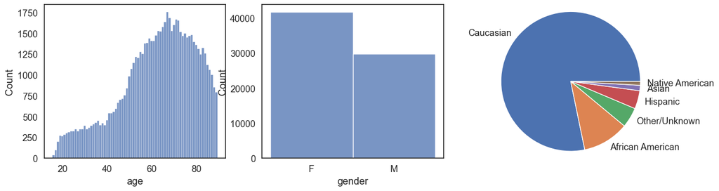

```python
_, axes = plt.subplots(1, 3, figsize=(16, 4))
sns.histplot(data=df, x="age", ax=axes[0], discrete=True)
sns.histplot(data=df, x="gender", ax=axes[1])

ethnicity_counts = df["ethnicity"].value_counts()
axes[2].pie(
    ethnicity_counts.values,
    labels=ethnicity_counts.index,
)
axes[2].axis("equal")
```

ชุดข้อมูลนี้ยังมีอัตราการพบ 6 โรค ได้แก่ มะเร็งเม็ดเลือดขาว ตับวาย ภาวะภูมิคุ้มกันบกพร่อง มะเร็งต่อมน้ำเหลือง ตับแข็ง และเอดส์ และเราลองพิจารณาการกระจายของแต่ละโรคตามเพศและเชื้อชาติ

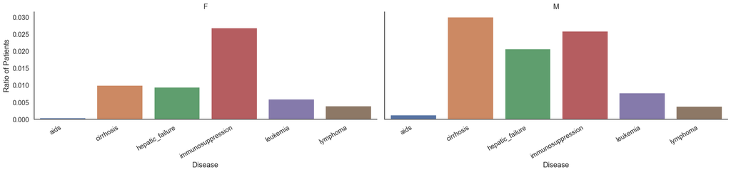

```python
bar_chart_of_diseases(df, group_by="gender")
```

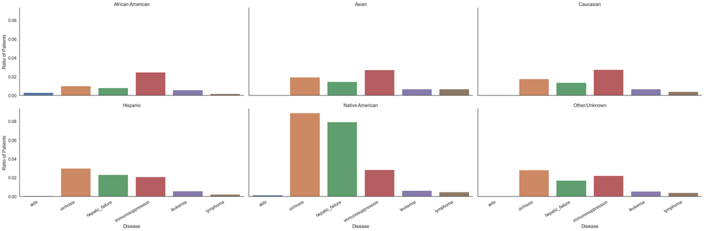

```python
bar_chart_of_diseases(df, group_by="ethnicity")
```

**🔍 ข้อค้นพบ**

- **อายุเฉลี่ย 62 ปี** มีการกระจายแบบเบ้ซ้าย กลุ่มอายุน้อยมีจำนวนน้อย
- **ผู้ชายมีจำนวนน้อยกว่า และพบโรคต่าง ๆ ในผู้ชายมากกว่า** โดยเฉพาะตับแข็ง ตับวาย เอดส์ และมะเร็งเม็ดเลือดขาว ลองคิดตามดูว่าเป็นเพราะอะไรได้บ้าง
- **77% ของผู้ป่วยเป็นคนผิวขาว**

หลังจากสำรวจข้อมูลแล้ว ลองสังเกตว่ามีอคติใดในข้อมูลบ้าง เช่น กลุ่มไหนมีจำนวนน้อยหรือมากเกินไป

ด้านล่างนี้คือตัวอย่างข้อมูลที่ได้รวบรวมไว้ สำหรับแต่ละชื่อ เราบันทึกค่าสูงสุดและต่ำสุดในชั่วโมงแรกและวันแรกของการเข้ารับการรักษา นอกจากนี้ยังมีข้อมูลประชากร เช่น อายุ เพศ เชื้อชาติ น้ำหนัก ส่วนสูง เป็นต้น

```python
display_feature_columns(df)
```

```
diasbp_invasive       diasbp                diasbp_noninvasive    heartrate
mbp_invasive          mbp                   mbp_noninvasive       resprate
spo2                  sysbp_invasive        sysbp                 sysbp_noninvasive
temp                  albumin               bilirubin             bun
calcium               creatinine            glucose               hco3
hemaglobin            hematocrit            inr                   lactate
platelets             potassium             sodium                wbc
arterial_pco2         arterial_ph           arterial_po2          pao2fio2ratio
```

โดยใช้คำนำหน้า `d1` และ `h1` แทนข้อมูลวันแรกและชั่วโมงแรกตามลำดับ และใช้คำต่อท้าย `max` และ `min` แทนค่าสูงสุดและต่ำสุดที่บันทึกในช่วงเวลานั้น

### การสร้างโมเดล

วันนี้เราจะโฟกัสไปที่เรื่องตับแข็ง จากข้อมูล เราพบว่าตับแข็งพบในผู้ชายมากกว่าผู้หญิง กราฟด้านล่างนี้แสดงอัตราผู้ป่วย ซึ่งจะเห็นว่าอัตราการเป็นตับแข็งของผู้ชายสูงกว่าผู้หญิงถึง 3 เท่า

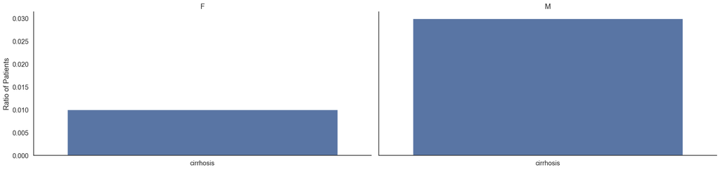

```python
bar_chart_of_cirrhosis(df, group_by="gender")
```

ฟีเจอร์ด้านล่างเหล่านี้ถูกเลือกมาสำหรับโมเดลพื้นฐาน ทั้งนี้สามารถลองเพิ่มเติมหรือลดฟีเจอร์ตามความเหมาะสมได้

```python
BASIC_FEATURES = [
    "d1_albumin_max", "d1_albumin_min",
    "d1_inr_max","d1_inr_min",
    "d1_bilirubin_max", "d1_bilirubin_min",
    "d1_platelets_min",
    "d1_mbp_min",
    "d1_creatinine_max",
    "d1_sodium_min",
    "d1_potassium_max",
    "d1_temp_max", "d1_temp_min",
    "d1_wbc_max", "d1_wbc_min",
    "d1_lactate_max"
]
```

เพื่อความสะดวก เราได้จัดเตรียมฟังก์ชันสำหรับสร้างและประเมินผลโมเดลไว้แล้ว โดยโมเดลที่ใช้จะเป็น random forest classifier หากต้องการดูรายละเอียดโค้ดฉบับเต็ม สามารถดูได้ที่ไฟล์ `workshop.py`

ก่อนจะไปต่อ ลองเลือกปัญหาที่คุณคุ้นเคยมาสักเรื่องเพื่อฝึกฝนสิ่งที่เราพูดถึงในส่วนแรก ๆ เมื่อเลือกคำถามได้แล้ว ลองคุยกันในทีมว่าเราควรเก็บข้อมูลอะไรจากผู้ป่วย ข้อมูลเหล่านั้นจะช่วยให้โมเดลทำงานได้ดีได้ยังไง มีกรณีการใช้งานอื่นใน ICU หรือเวชปฏิบัติที่สามารถนำวิธีนี้ไปประยุกต์ใช้ได้หรือไม่ ข้อมูลมีรูปแบบเหมือนกันหรือไม่ สามารถใช้วิธีการทำความสะอาดข้อมูลเดียวกันได้หรือไม่

หากนึกไม่ออก ลองเลือกปัญหาสักข้อจากลิสต์ปัญหาต่อไปนี้

1. ประเมินภาวะกล้ามเนื้อหัวใจขาดเลือด จากสัญญาณ ECG (คลื่นไฟฟ้าหัวใจ)
2. การตรวจหามะเร็งปอดจากภาพถ่ายรังสีทรวงอก
3. ปรับขนาดยาลดระดับน้ำตาลในเลือดจากข้อมูลระดับน้ำตาลในเลือด
4. การทำนายภาวะติดเชื้อใน ICU
5. ระบบเตือนภัยล่วงหน้า (EWS) สำหรับภาวะทรุดหนัก
6. การสกัดข้อมูลจากบันทึกการรักษาแบบบรรยาย (free-text) ของแพทย์ เพื่อนำไปใช้ในการวิเคราะห์
7. การบริหารจัดการเตียงผู้ป่วย

ลองเสนอไอเดียในกลุ่มได้เลย

## ส่วนที่ 3: การติดตามผลโมเดล AI ของคุณ

Confusion matrix เป็นเครื่องมือพื้นฐานสำหรับประเมินประสิทธิภาพของ classification model (โมเดลจำแนกประเภท) โดยเป็นตารางที่สรุปจำนวนการทำนายที่ถูกต้องและไม่ถูกต้องของโมเดล แยกตามแต่ละคลาส ตารางนี้แสดงจำนวน true positive (TP), true negative (TN), false positive (FP) และ false negative (FN) ซึ่งช่วยให้เห็นไม่เพียงแต่ความแม่นยำโดยรวม แต่ยังเห็นประเภทของข้อผิดพลาดที่โมเดลทำ การวิเคราะห์นี้ช่วยให้สามารถระบุได้ว่าโมเดลมีอคติต่อคลาสใดหรือมีแนวโน้มทำผิดแบบใดซ้ำ ๆ

[figure not shown]

เราใช้ confusion matrix ในการคำนวนค่าความแม่นยำต่าง ๆ เช่น accuracy, precision, และ recall (sensitivity)

- **Accuracy** วัดความแม่นยำ ซึ่งคือสัดส่วนของการทำนายที่ถูกต้องต่อการทำนายทั้งหมด
- **Precision** วัดความแม่นยำของการทำนายผลที่เป็นบวก นั่นคือสัดส่วนของการทำนายที่ถูกต้องในการทำนายที่เป็นบวกทั้งหมด
- **Recall** วัดความครบถ้วน ซึ่งคือสัดส่วนของการทำนายที่เป็นบวกและถูกต้องต่อจำนวนตัวที่เป็นบวกจริงทั้งหมด

ตัวชี้วัดเหล่านี้ช่วยให้เข้าใจประสิทธิภาพของโมเดลอย่างรอบด้าน โดยเฉพาะในงานทางการแพทย์ที่ข้อผิดพลาดบางประเภทอาจมีผลกระทบอย่างมีนัยสำคัญ

ก่อนที่เราจะเข้าสู่ช่วงถัดไป ลองพิจารณาว่าควรใช้ตัวชี้วัดใดในการประเมินผลสำหรับปัญหาที่เลือกไว้ก่อนหน้านี้ หรือควรมีตัวชี้วัดอื่น ๆ ที่ มีความเหมาะสมมากกว่าตัวชี้วัดเหล่านี้หรือไม่

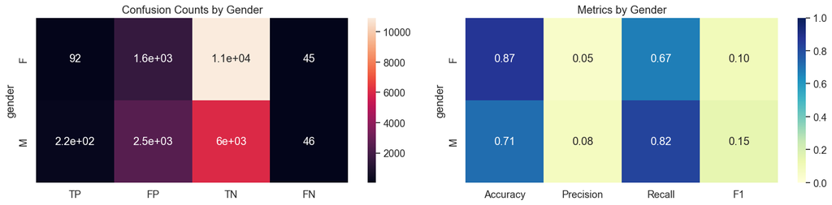

```python
result_df = train_and_evaluate(df=df,
                               numerical_features=BASIC_FEATURES,
                               categorical_features=["gender"],
                               target="cirrhosis",
                              )
plot_model_result(result_df)
```

จะเห็นว่าค่า Accuracy และ Recall ค่อนข้างสูง แต่นี่เพียงพอแล้วหรือไม่ หรือเราควรพิจารณาเรื่องอื่นเพิ่มเติม

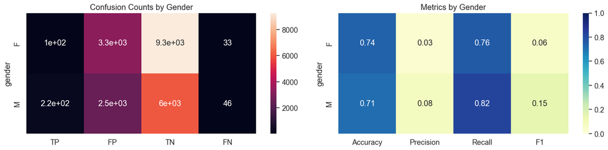

```python
result_df = train_and_evaluate(df=df,
                               numerical_features=BASIC_FEATURES,
                               categorical_features=["gender"],
                               target="cirrhosis",
                               everyone_as_male=True
                               )
plot_model_result(result_df)
```

คำตอบคือไม่เพียงพอ เพราะหากมีการระบุเพศของผู้ป่วยหญิงผิดเป็นชาย ผลการทำนายจะเปลี่ยนแปลงอย่างมีนัยสำคัญ ทั้ง ๆ ที่ไม่มีเหตุผลทางชีววิทยาที่มาสนับสนุนเลย

### การลดอคติของโมเดล

ก่อนที่จะพิจารณาวิธีการลดอคติเรื่องเพศ คุณสามารถอธิบายได้หรือไม่ว่าอคตินี้เกิดขึ้นได้อย่างไร

เพื่อแก้ไขอคติที่เกิดขึ้น เราจึงปรับชุดข้อมูลใหม่ให้สะท้อนความเป็นจริง โดยการทำให้สัดส่วนของผู้ป่วยชายและผู้ป่วยหญิงใกล้เคียงกันมากขึ้น นั่นคือตัดลบข้อมูลเพศหญิงที่ไม่เป็นโรคอย่างสุ่ม และลบข้อมูลเพศชายที่เป็นโรคอย่างสุ่ม จนมีอัตราส่วนผู้ป่วยใกล้เคียงกัน ด้วยวิธีนี้ โมเดลจะได้เรียนรู้ว่าไม่มีความแตกต่างระหว่างสองเพศในแง่ของความเสี่ยง และในที่สุดก็ช่วยลดหรือขจัดอคติออกไปได้

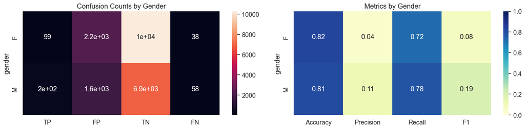

```python
result_df = train_and_evaluate(df=df,
                               numerical_features=BASIC_FEATURES,
                               categorical_features=["gender"],
                               target="cirrhosis",
                               mitigate_bias=mitigate_gender_bias,
                               )
plot_model_result(result_df)
```

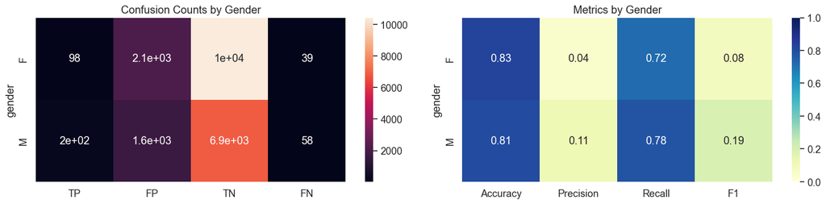

```python
result_df = train_and_evaluate(df=df,
                               numerical_features=BASIC_FEATURES,
                               categorical_features=["gender"],
                               target="cirrhosis",
                               mitigate_bias=mitigate_gender_bias,
                               everyone_as_male=True
                               )
plot_model_result(result_df)
```

เมื่อเราสร้างโมเดลโดยใช้การลดอคติทางเพศ การระบุเพศผิดจะไม่ส่งผลกระทบต่อผลลัพธ์มากนัก ในการสร้างโมเดล AI การใช้ชุดข้อมูลที่ไม่สมดุลเป็นปัญหาสำคัญโดยเฉพาะในทางการแพทย์ เนื่องจากโมเดลอาจเรียนรู้ที่จะให้ความสำคัญกับประชากรกลุ่มที่เป็น ส่วนใหญ่มากกว่า ส่งผลให้การตรวจพบกลุ่มที่มีจำนวนน้อยแต่มีความสำคัญลดลง ในกรณีนี้ อัตราผู้ป่วยชายมากกว่าหญิง 3 เท่า โมเดลจึงมีแนวโน้มทำนายว่าผู้ชายเป็นตับแข็งและผู้หญิงไม่เป็นตับแข๊ง

ท้ายที่สุด ลองพิจารณาประเด็นต่อไปนี้:

- คุณคิดว่ามีตัวอย่างใดที่อคติช่วยให้โมเดลมีความแม่นยำมากขึ้น หรืออคติมีประโยชน์ในบางกรณีหรือไม่
- ในตัวอย่างดังกล่าว คุณจะทราบได้อย่างไรว่าอคตินั้นยุติธรรมหรือไม่ เหมาะสมหรือไม่
- จะสามารถป้องกันอคติในวงจร machine learning ได้อย่างไร
- จะทราบได้อย่างไรว่า ChatGPT ปลอดภัยจากอคติ ควรตั้งคำถามใดเพื่อหาคำตอบ
- ควรใช้งาน ChatGPT อย่างไรเมื่อทราบว่ามีอคติอยู่